# ggplot2 color scales

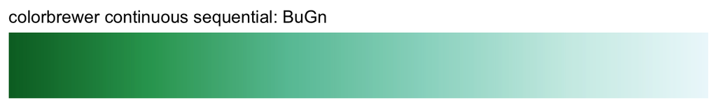

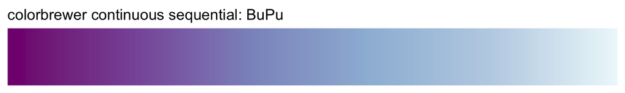

[figure not shown]

[figure not shown]

[figure not shown]

[figure not shown]

[figure not shown]

[figure not shown]

[figure not shown]

[figure not shown]

[figure not shown]

[6 more figures not shown]

The discrete colorbrewer scales are all called via `scale_fill_brewer(type = "seq", palette = "name")`, where `name` is the name of the palette, e.g. `palette = "Blues"`.

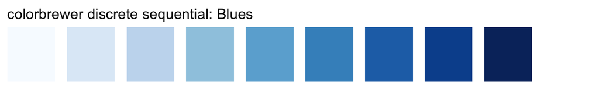

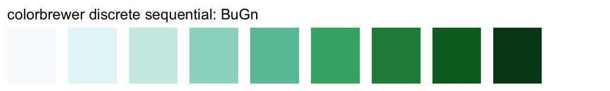

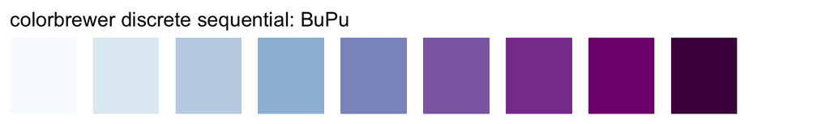

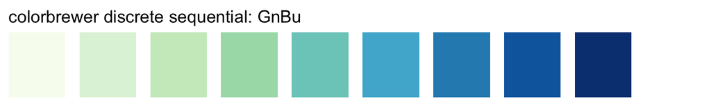

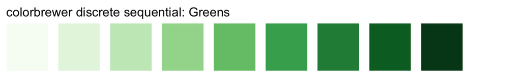

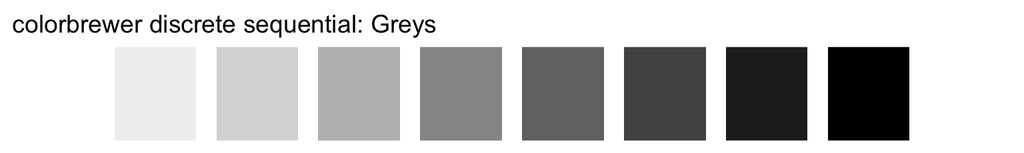

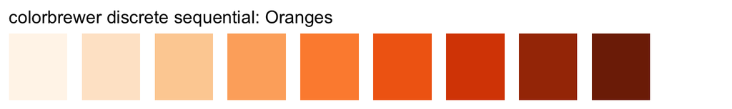

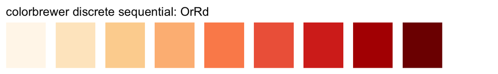

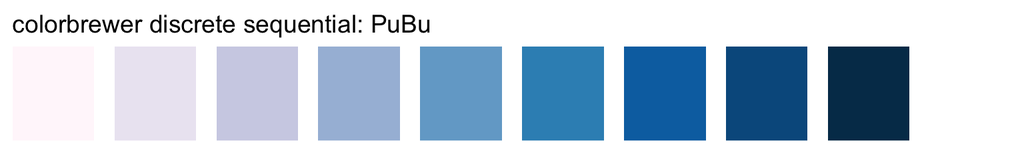

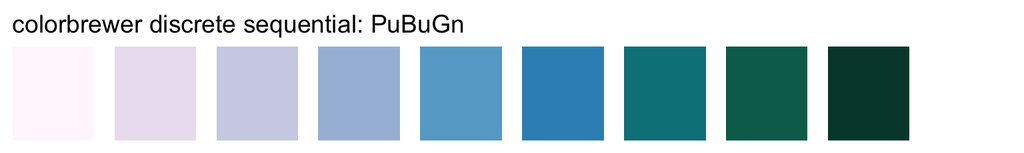

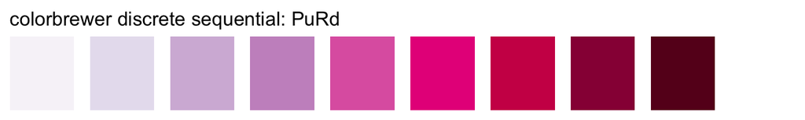

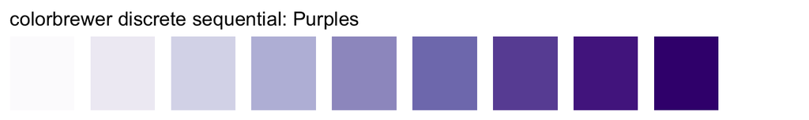

[6 more figures not shown]

## Diverging scales

Diverging scales convey the ordering or magnitude of an effect in two directions. These scales may exist in discrete or continuous forms or both.

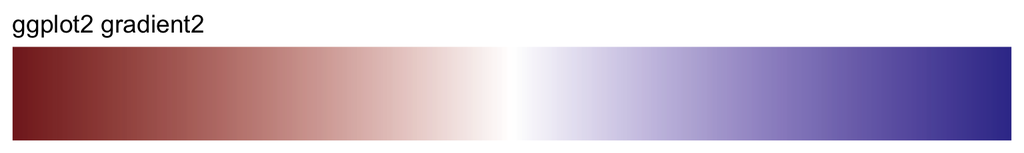

The continuous diverging colorbrewer scales are all called via `scale_fill_distiller(type = "div", palette = "name")`, where `name` is the name of the palette, e.g. `palette = "BrBG"`.

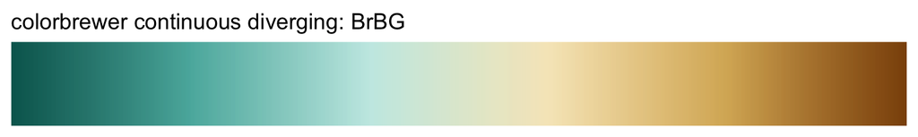

[figure not shown]

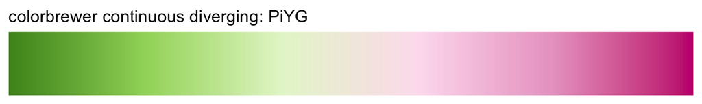

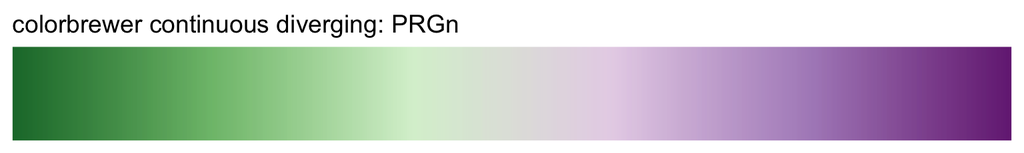

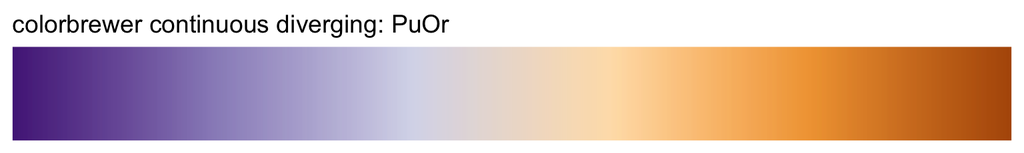

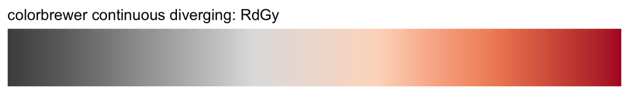

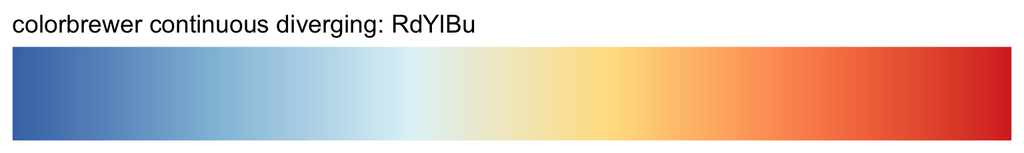

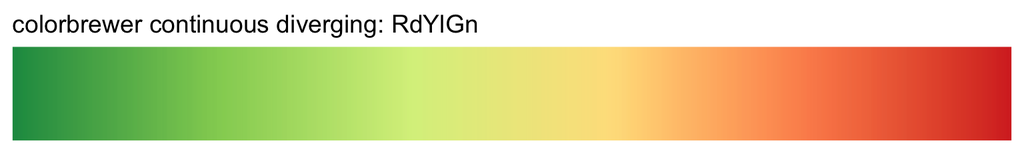

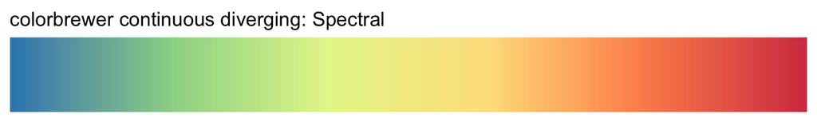

The discrete diverging colorbrewer scales are all called via `scale_fill_brewer(type = "div", palette = "name")`, where `name` is the name of the palette, e.g. `palette = "BrBG"`.

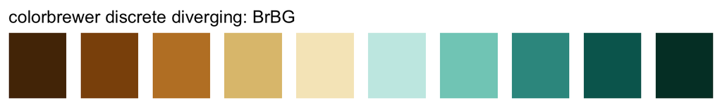

[figure not shown]

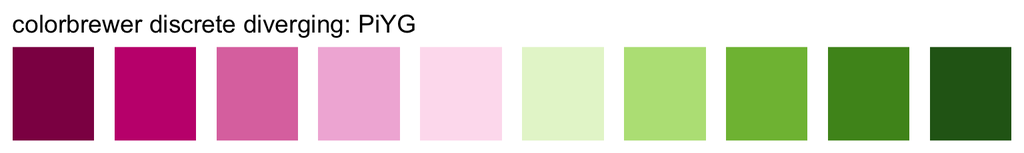

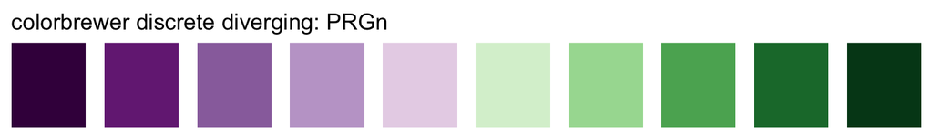

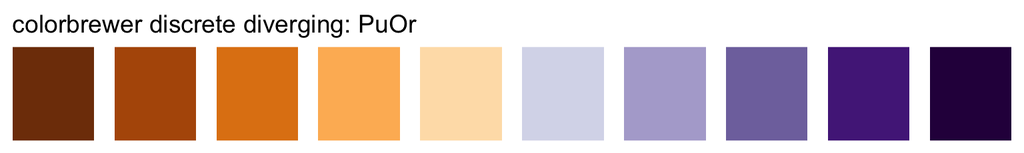

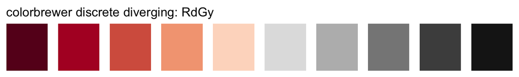

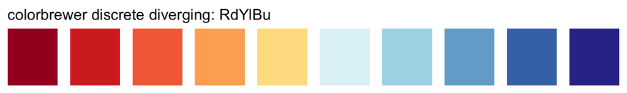

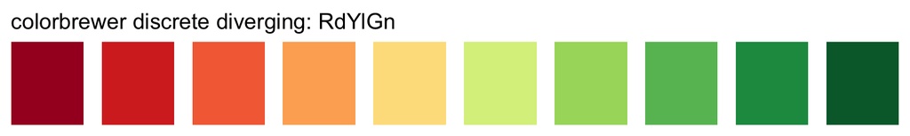

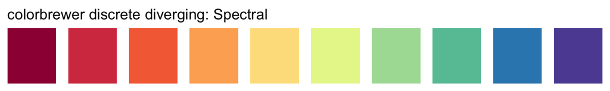